# Go_RNA

Boris_Yosia_Sara_Peter_Shravanti_Martha

12/2/2019

Let us clean our environment.

```r
rm(list = ls())
```

Now, we can download the files needed from our Git repository

```r
download.file("https://raw.githubusercontent.com/Boris-alladassi/Go_RNA_Final_project/master/DEgenes.counts.matrix", destfile = "./DEgenes.counts.matrix")

download.file("https://raw.githubusercontent.com/Boris-alladassi/Go_RNA_Final_project/master/Fourth_DEgenes.counts.matrix", destfile = "./Fourth_DEgenes.counts.matrix")

download.file("https://raw.githubusercontent.com/Boris-alladassi/Go_RNA_Final_project/master/AgriGO_output_Dec_6th_19.txt", destfile = "./GO_enrichment.txt")
```

OK let us load all the packages required for this pipeline.

```r
# For the differential expression analysis
if (!requireNamespace("BiocManager", quietly = TRUE)){
    install.packages("BiocManager")
}

if(!require(EBSeq)){
  BiocManager::install("EBSeq")
  library(EBSeq)
}
```

[output not shown]

```r
# To draw the Venn diagram
if(!require(VennDiagram)){
    install.packages("VennDiagram", dependencies = T)
    library(VennDiagram)
}
# Tidyverse
if(!require(tidyverse)){
    install.packages("tidyverse", dependencies = T)
    library(tidyverse)
}
# For plotting the heatmaps
if(!require(pheatmap)){
    install.packages("pheatmap", dependencies = T)
    library(pheatmap)
}
if(!require(ggpubr)){
    install.packages("ggpubr", dependencies = T)
    library(ggpubr)
}
```

## Differential expression analysis

##### Differential expression analysis for second leaf

```r
DEgenes_matrix = read.delim(file = "./DEgenes.counts.matrix", header = T)

name_column <- c("DEG", "WT_-_N_R1","WT_-_N_R2", "WT_-_N_R3",
                 "WT_+_N_R1","WT_+_N_R2", "WT_+_N_R3",
                 "atg1_-_N_R1","atg1_-_N_R2","atg1_-_N_R3",
                 "atg1_+_N_R1","atg1_+_N_R2","atg1_+_N_R3",
                 "atg2_-_N_R1","atg2_-_N_R2","atg2_-_N_R3",
                 "atg2_+_N_R1", "atg2_+_N_R2", "atg2_+_N_R3")

colnames(DEgenes_matrix) <- name_column

DEgenes_with_N1 <- DEgenes_matrix %>% select("DEG", "WT_+_N_R1", "WT_+_N_R2","WT_+_N_R3",
                                     "atg1_+_N_R1", "atg1_+_N_R2", "atg1_+_N_R3",) %>% column_to_rownames(., var = "DEG") %>% as.matrix()


DEgenes_with_N2 <- DEgenes_matrix %>% select("DEG", "WT_+_N_R1", "WT_+_N_R2","WT_+_N_R3",
                                     "atg2_+_N_R1", "atg2_+_N_R2", "atg2_+_N_R3") %>% column_to_rownames(., var = "DEG") %>% as.matrix()

###################################3

DEgenes_without_N1 <- DEgenes_matrix %>% select("DEG", "WT_-_N_R1","WT_-_N_R2", "WT_-_N_R3",
                                        "atg1_-_N_R1","atg1_-_N_R2","atg1_-_N_R3") %>% column_to_rownames(., var = "DEG") %>% as.matrix()


DEgenes_without_N2 <- DEgenes_matrix %>% select("DEG", "WT_-_N_R1","WT_-_N_R2", "WT_-_N_R3",
                                        "atg2_-_N_R1","atg2_-_N_R2","atg2_-_N_R3") %>% column_to_rownames(., var = "DEG") %>% as.matrix()
```

DEG for condition with Nitrogen

```r
#Wildtype vs atg1 with N
sizes_with_N1 <- MedianNorm(DEgenes_with_N1)

Ebseq_out_with_N1 <- EBTest(Data = DEgenes_with_N1, Conditions = as.factor(c("wt", "wt", "wt", "mut", "mut", "mut")), sizeFactors = sizes_with_N1, maxround = 10)
```

```
## Removing transcripts with 100 th quantile < = 0
## 30989 transcripts will be tested
```

```
## iteration 1 done
```

```
## time 11.53
```

```
## iteration 2 done
```

```
## time 4.51
```

```
## iteration 3 done
```

```
## time 4.57
```

```
## iteration 4 done
```

```
## time 4.75
```

```
## iteration 5 done
```

```
## time 4.17
```

```
## iteration 6 done
```

```
## time 4.03
```

```
## iteration 7 done
```

```
## time 4.15
```

```
## iteration 8 done
```

```
## time 4.5
```

```
## iteration 9 done
```

```
## time 4.7
```

```
## iteration 10 done
```

```
## time 4.69
```

```r
DEG_FDR_with_N1 <- GetDEResults(Ebseq_out_with_N1, FDR = 0.05, SmallNum = 0.001)

Second_N1_PP <- DEG_FDR_with_N1$PPMat %>% as.data.frame() %>%
  rownames_to_column(., var = "Genes") %>% filter(., PPEE < 0.05)
```

```r
#Wildtype vs atg2 with N
sizes_with_N2 <- MedianNorm(DEgenes_with_N2)

Ebseq_out_with_N2 <- EBTest(Data = DEgenes_with_N2, Conditions = as.factor(c("wt", "wt", "wt", "mut", "mut", "mut")), sizeFactors = sizes_with_N2, maxround = 10)
```

```
## Removing transcripts with 100 th quantile < = 0
## 30926 transcripts will be tested
```

```
## iteration 1 done
```

```
## time 11.4
```

```
## iteration 2 done
```

```
## time 5.14
```

```
## iteration 3 done
```

```
## time 4.64
```

```
## iteration 4 done
```

```
## time 4.82
```

```
## iteration 5 done
```

```
## time 5
```

```
## iteration 6 done
```

```
## time 5.11
```

```
## iteration 7 done
```

```
## time 4.8
```

```
## iteration 8 done
```

```
## time 4.84
```

```
## iteration 9 done
```

```
## time 4.74
```

```
## iteration 10 done
```

```
## time 5.03
```

```r
DEG_FDR_with_N2 <- GetDEResults(Ebseq_out_with_N2, FDR = 0.05, SmallNum = 0.001)

Second_N2_PP <- DEG_FDR_with_N2$PPMat %>% as.data.frame() %>%
  rownames_to_column(., var = "Genes") %>% filter(., PPEE < 0.05)
```

```r
#Wildtype vs atg1 without N
sizes_without_N1 <- MedianNorm(DEgenes_without_N1)

Ebseq_out_without_N1 <- EBTest(Data = DEgenes_without_N1, Conditions = as.factor(c("wt", "wt", "wt", "mut", "mut", "mut")), sizeFactors = sizes_without_N1, maxround = 10)
```

```
## Removing transcripts with 100 th quantile < = 0
## 31132 transcripts will be tested
```

```
## iteration 1 done
```

```
## time 8
```

```
## iteration 2 done
```

```
## time 4.7
```

```
## iteration 3 done
```

```
## time 4.64
```

```
## iteration 4 done
```

```
## time 4.41
```

```
## iteration 5 done
```

```
## time 4.63
```

```
## iteration 6 done
```

```
## time 4.45
```

```
## iteration 7 done
```

```
## time 4.28
```

```
## iteration 8 done
```

```
## time 4.36
```

```
## iteration 9 done
```

```
## time 4.2
```

```
## iteration 10 done
```

```
## time 4.44
```

```r
DEG_FDR_without_N1 <- GetDEResults(Ebseq_out_without_N1, FDR = 0.05, SmallNum = 0.001)

Second_1_PP <- DEG_FDR_without_N1$PPMat %>% as.data.frame() %>%
  rownames_to_column(., var = "Genes") %>% filter(., PPEE < 0.05)
```

```r
#Wildtype vs atg2 without N
sizes_without_N2 <- MedianNorm(DEgenes_without_N2)

Ebseq_out_without_N2 <- EBTest(Data = DEgenes_without_N2, Conditions = as.factor(c("wt", "wt", "wt", "mut", "mut", "mut")), sizeFactors = sizes_without_N2, maxround = 10)
```

```
## Removing transcripts with 100 th quantile < = 0
## 30943 transcripts will be tested
```

```
## iteration 1 done
```

```
## time 6.34
```

```
## iteration 2 done
```

```
## time 4.41
```

```
## iteration 3 done
```

```
## time 4.47
```

```
## iteration 4 done
```

```
## time 4.36
```

```
## iteration 5 done
```

```
## time 4.23
```

```
## iteration 6 done
```

```
## time 4.24
```

```
## iteration 7 done
```

```
## time 4.53
```

```
## iteration 8 done
```

```
## time 4.28
```

```
## iteration 9 done
```

```
## time 4.4
```

```
## iteration 10 done
```

```
## time 4.41
```

```r
DEG_FDR_without_N2 <- GetDEResults(Ebseq_out_without_N2, FDR = 0.05, SmallNum = 0.001)

Second_2_PP <- DEG_FDR_without_N2$PPMat %>% as.data.frame() %>%
  rownames_to_column(., var = "Genes") %>% filter(., PPEE < 0.05)
```

We will now extract consitent DEgenes across mutant and conditions of Nitrogen to be used for the GO enrichment analysis.

```r
DEG_without_N <- intersect(DEG_FDR_without_N2$DEfound, DEG_FDR_without_N1$DEfound)

DEG_with_N <- intersect(DEG_FDR_with_N2$DEfound, DEG_FDR_with_N1$DEfound)

DEG_all <- intersect(DEG_FDR_without_N2$DEfound, DEG_FDR_without_N1$DEfound) %>%
  intersect(.,DEG_FDR_with_N2$DEfound) %>%
  intersect(., DEG_FDR_with_N1$DEfound) %>% as.data.frame()

write_csv(DEG_all, "DEG_all.csv")
```

### Scatter plot for Second Leaf

The scatter plot is only for significant(FDR <0.05) DE genes for both mutants under each Nitrogen conditions.

```r
########## With Nitrogen
Second_N1_FC <- PostFC(Ebseq_out_with_N1, SmallNum = 0.001)$PostFC %>% as.data.frame() %>% rownames_to_column(., var = "Genes") %>%
  rename(., `log2FC_atg1/wt` = `.`) %>%
  mutate(`log2FC_atg1/wt` = log2(`log2FC_atg1/wt`))

Second_N2_FC <- PostFC(Ebseq_out_with_N2, SmallNum = 0.001)$PostFC %>% as.data.frame() %>% rownames_to_column(., var = "Genes") %>%
  rename(., `log2FC_atg2/wt` = `.`) %>%
  mutate(`log2FC_atg2/wt` = log2(`log2FC_atg2/wt`))

Significant_DEG_N <- DEG_with_N %>% as.data.frame() %>% rename(., Genes = `.`)

Second_N_PostFC <- inner_join(Second_N1_FC, Second_N2_FC, by = "Genes") %>%
  inner_join(., Significant_DEG_N, by = "Genes")
########## Without Nitrogen
Second_1_FC <- PostFC(Ebseq_out_without_N1, SmallNum = 0.001)$PostFC %>% as.data.frame() %>% rownames_to_column(., var = "Genes") %>%
  rename(., `log2FC_atg1/wt` = `.`) %>%
  mutate(`log2FC_atg1/wt` = log2(`log2FC_atg1/wt`))

Second_2_FC <- PostFC(Ebseq_out_without_N2, SmallNum = 0.001)$PostFC %>% as.data.frame() %>% rownames_to_column(., var = "Genes") %>%
  rename(., `log2FC_atg2/wt` = `.`) %>%
  mutate(`log2FC_atg2/wt` = log2(`log2FC_atg2/wt`))

Significant_DEG <- DEG_without_N %>% as.data.frame() %>% rename(., Genes = `.`)

Second_PostFC <- inner_join(Second_1_FC, Second_2_FC, by = "Genes")%>%
  inner_join(., Significant_DEG, by = "Genes")
```

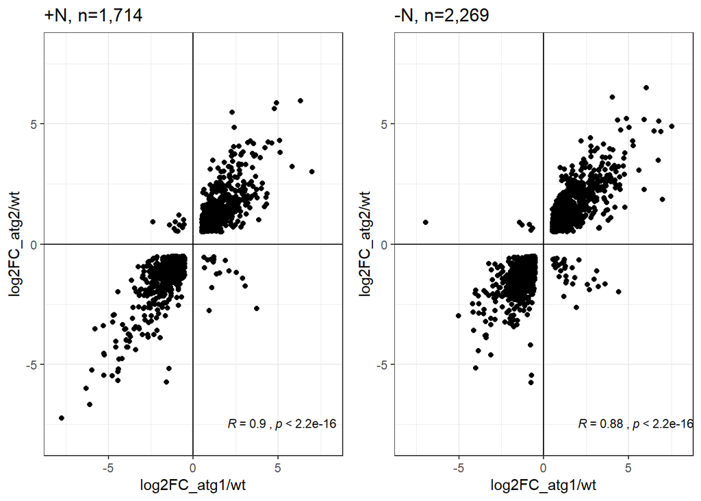

```r
scatter1<- ggplot(Second_N_PostFC, aes(x = `log2FC_atg1/wt`, y = `log2FC_atg2/wt`)) +
  geom_point() + theme_bw() + geom_hline(yintercept = 0) + geom_vline(xintercept = 0) +
  expand_limits(x = c(-8, 8), y = c(-8, 8)) + ggtitle( "+N, n=1,714") +
  stat_cor(method = "pearson", label.x = 2, label.y = -7.5, size = 3)


scatter2<-ggplot(Second_PostFC, aes(x = `log2FC_atg1/wt`, y = `log2FC_atg2/wt`)) + geom_point() +
  theme_bw() + geom_hline(yintercept = 0) + geom_vline(xintercept = 0) +
  expand_limits(x = c(-8, 8), y = c(-8, 8)) + ggtitle("-N, n=2,269") +
  stat_cor(method = "pearson", label.x = 2, label.y = -7.5, size = 3)

ggarrange(scatter1, scatter2)
```

### Heatmap plot for second Leaf

Let us prepare the data. Here, we are using the transcripts with a posterior probality of equal expression less 0.05 for both mutants in -N and +N conditions

```r
Second_with_N_PP <- inner_join(Second_N1_PP, Second_N2_PP, by = "Genes")
Second_without_N_PP <- inner_join(Second_1_PP, Second_2_PP, by = "Genes")
Second_PP <- full_join(Second_with_N_PP, Second_without_N_PP, by = "Genes") %>% select(Genes)

Second_FC_all <- inner_join(Second_PP, DEgenes_matrix, by = c("Genes" = "DEG"))
```

```r
Second_FC <- Second_FC_all %>% select("Genes", "WT_-_N_R1","WT_-_N_R2", "WT_-_N_R3",
                                        "atg1_-_N_R1","atg1_-_N_R2","atg1_-_N_R3",
                                        "atg2_-_N_R1","atg2_-_N_R2","atg2_-_N_R3") %>%
  na.omit() %>% mutate(Wt_vg = (`WT_-_N_R1` + `WT_-_N_R2` +`WT_-_N_R3`)/3 ) %>%
  mutate_if(is.numeric, ~-log2((./Wt_vg)+0.00001)) %>% select(-Wt_vg)


Second_FC_N <- Second_FC_all %>% select("Genes","WT_+_N_R1","WT_+_N_R2", "WT_+_N_R3",
                                        "atg1_+_N_R1","atg1_+_N_R2","atg1_+_N_R3",
                                        "atg2_+_N_R1", "atg2_+_N_R2", "atg2_+_N_R3")%>%
  na.omit() %>% mutate(Wt_vg = (`WT_+_N_R1` + `WT_+_N_R2` +`WT_+_N_R3`)/3 ) %>%
  mutate_if(is.numeric, ~-log2((./Wt_vg)+0.00001)) %>% select(-Wt_vg)

Second_FC_Heat <- merge(Second_FC_N, Second_FC, by = "Genes") %>%
  select(-Genes) %>% na.omit() %>% arrange(desc(`atg1_+_N_R2`))
Second_FC_Heat[Second_FC_Heat > 3] <- 4
Second_FC_Heat[Second_FC_Heat < -3] <- -4

Second_FC_matrix <- as.matrix(Second_FC_Heat)
```

Let us now plot the heatmap

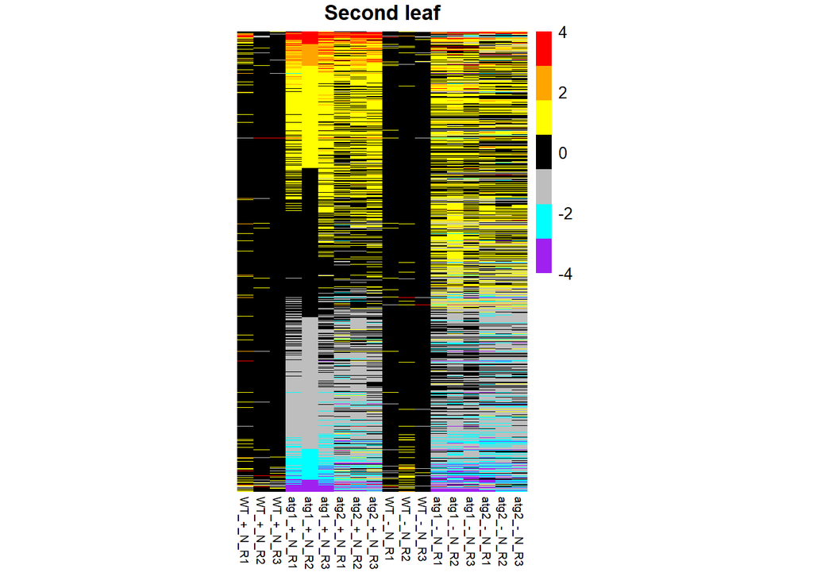

```r
pheatmap(Second_FC_matrix, cluster_rows = F, cluster_cols = F,
         col= c("purple","cyan","grey","black", "yellow", "orange", "red"),
         legend_labels = "-log2FC", show_rownames = F,
         fontsize_col = 7, cellwidth = 10, main = "Second leaf")
```

### Principal component analysis for Second leaf

```r
DEgenes_matrix_pca <- DEgenes_matrix %>% column_to_rownames(., var = "DEG") %>% as.matrix()

Second_sizes_all <- MedianNorm(DEgenes_matrix_pca)

Norm_DEgenes_matrix_pca <- GetNormalizedMat(DEgenes_matrix_pca, Second_sizes_all)

Second_PCA_data <- Norm_DEgenes_matrix_pca %>% as.data.frame() %>%
  rownames_to_column(., var = "Genes") %>%
  inner_join(., DEG_all, by = c("Genes"= ".")) %>%
  column_to_rownames(., var = "Genes") %>% as.matrix() %>%
  t() %>% as.data.frame() %>% rownames_to_column(., var = "Genotypes") %>%
  mutate(Group = ifelse(grepl("WT_-", Genotypes), "WT_-N",
                        ifelse(grepl("WT_+", Genotypes), "WT_+N",
                        ifelse(grepl("atg1_-", Genotypes),"atg1_-N",
                        ifelse(grepl("atg1_+", Genotypes),"atg1_+N",
                        ifelse(grepl("atg2_-", Genotypes),"atg2_-N", "atg2_+N")))))) %>%
  select(Group, Genotypes, everything())
library(FactoMineR)
library(factoextra)
```

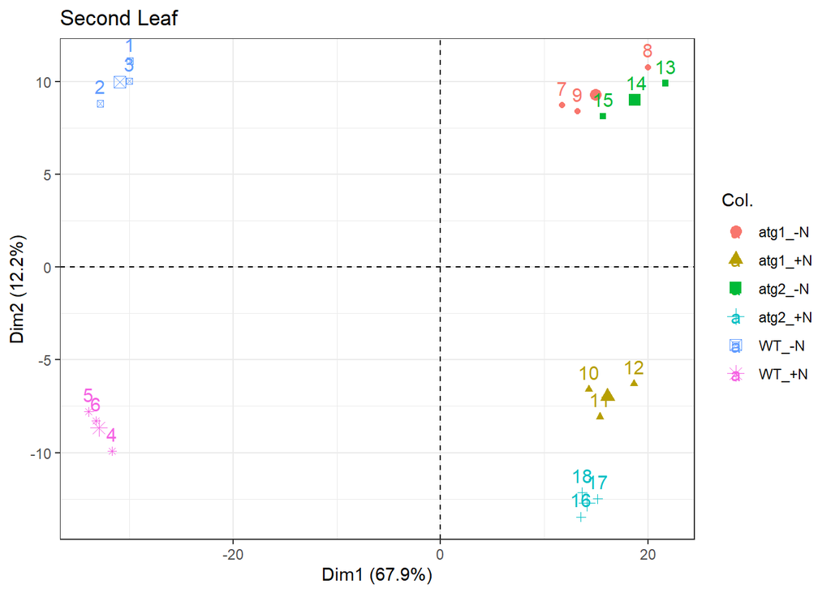

```r
pca = PCA(Second_PCA_data[,-(1:2)], scale.unit = T, ncp = 5, graph = F)

biplot = fviz_pca_ind(pca,  col.ind= Second_PCA_data$Group,
                      title = "Second Leaf") +
  theme_bw()

biplot
```

##### Differential expression analysis for fourth leaf

```r
Fourth_DEgenes_matrix = read.delim(file = "./Fourth_DEgenes.counts.matrix", header = T)

name_column <- c("DEG", "WT_-_N_R1","WT_-_N_R2", "WT_-_N_R3",
                 "WT_+_N_R1","WT_+_N_R2", "WT_+_N_R3",
                 "atg1_-_N_R1","atg1_-_N_R3",
                 "atg1_+_N_R1","atg1_+_N_R2","atg1_+_N_R3",
                 "atg2_-_N_R1","atg2_-_N_R2","atg2_-_N_R3",
                 "atg2_+_N_R1", "atg2_+_N_R2", "atg2_+_N_R3")

colnames(Fourth_DEgenes_matrix) <- name_column

##################
Fourth_DEgenes_with_N1 <- Fourth_DEgenes_matrix %>%
  select("DEG", "WT_+_N_R1", "WT_+_N_R2","WT_+_N_R3",
         "atg1_+_N_R1", "atg1_+_N_R2", "atg1_+_N_R3",) %>%
  column_to_rownames(., var = "DEG") %>% as.matrix()


Fourth_DEgenes_with_N2 <- Fourth_DEgenes_matrix %>%
  select("DEG", "WT_+_N_R1", "WT_+_N_R2","WT_+_N_R3",
         "atg2_+_N_R1", "atg2_+_N_R2", "atg2_+_N_R3") %>%
  column_to_rownames(., var = "DEG") %>% as.matrix()

###################

Fourth_DEgenes_without_N1 <- Fourth_DEgenes_matrix %>%
  select("DEG", "WT_-_N_R1","WT_-_N_R2", "WT_-_N_R3",
         "atg1_-_N_R1","atg1_-_N_R3") %>%
  column_to_rownames(., var = "DEG") %>% as.matrix()


Fourth_DEgenes_without_N2 <- Fourth_DEgenes_matrix %>%
  select("DEG", "WT_-_N_R1","WT_-_N_R2", "WT_-_N_R3",
         "atg2_-_N_R1","atg2_-_N_R2","atg2_-_N_R3") %>%
  column_to_rownames(., var = "DEG") %>% as.matrix()
```

DEG for condition with Nitrogen

```r
#Fourth leaf : Wildtype vs atg1 with N
Fourth_sizes_with_N1 <- MedianNorm(Fourth_DEgenes_with_N1)

Fourth_Ebseq_out_with_N1 <- EBTest(Data = Fourth_DEgenes_with_N1,
                            Conditions = as.factor(c("wt", "wt", "wt",
                                                     "mut", "mut", "mut")),
                            sizeFactors = Fourth_sizes_with_N1, maxround = 10)
```

```
## Removing transcripts with 100 th quantile < = 0
## 31175 transcripts will be tested
```

```
## iteration 1 done
```

```
## time 7.42
```

```
## iteration 2 done
```

```
## time 5.22
```

```
## iteration 3 done
```

```
## time 4.59
```

```
## iteration 4 done
```

```
## time 4.71
```

```
## iteration 5 done
```

```
## time 4.78
```

```
## iteration 6 done
```

```
## time 4.79
```

```
## iteration 7 done
```

```
## time 4.77
```

```
## iteration 8 done
```

```
## time 4.56
```

```
## iteration 9 done
```

```
## time 4.96
```

```
## iteration 10 done
```

```
## time 4.59
```

```r
Fourth_DEG_FDR_with_N1 <- GetDEResults(Fourth_Ebseq_out_with_N1, FDR = 0.05, SmallNum = 0.001)

Fourth_N1_PP <- Fourth_DEG_FDR_with_N1$PPMat %>% as.data.frame() %>%
  rownames_to_column(., var = "Genes") %>% filter(., PPEE < 0.05)
```

```r
# Fourth leaf: Wildtype vs atg2 with N
Fourth_sizes_with_N2 <- MedianNorm(Fourth_DEgenes_with_N2)

Fourth_Ebseq_out_with_N2 <- EBTest(Data = Fourth_DEgenes_with_N2,
                            Conditions = as.factor(c("wt", "wt", "wt",
                                                     "mut", "mut", "mut")),
                            sizeFactors = Fourth_sizes_with_N2, maxround = 10)
```

```
## Removing transcripts with 100 th quantile < = 0
## 31100 transcripts will be tested
```

```
## iteration 1 done
```

```
## time 6.04
```

```
## iteration 2 done
```

```
## time 4.03
```

```
## iteration 3 done
```

```
## time 4.08
```

```
## iteration 4 done
```

```
## time 4.53
```

```
## iteration 5 done
```

```
## time 4.08
```

```
## iteration 6 done
```

```
## time 3.95
```

```
## iteration 7 done
```

```
## time 3.93
```

```
## iteration 8 done
```

```
## time 3.75
```

```
## iteration 9 done
```

```
## time 3.78
```

```
## iteration 10 done
```

```
## time 4.03
```

```r
Fourth_DEG_FDR_with_N2 <- GetDEResults(Fourth_Ebseq_out_with_N2, FDR = 0.05, SmallNum = 0.001)

Fourth_N2_PP <- Fourth_DEG_FDR_with_N2$PPMat %>% as.data.frame() %>%
  rownames_to_column(., var = "Genes") %>% filter(., PPEE < 0.05)
```

```r
#Fourth leaf: Wildtype vs atg1 without N
Fourth_sizes_without_N1 <- MedianNorm(Fourth_DEgenes_without_N1)

Fourth_Ebseq_out_without_N1 <- EBTest(Data = Fourth_DEgenes_without_N1,
                               Conditions = as.factor(c("wt", "wt", "wt",
                                                        "mut","mut")),
                               sizeFactors = Fourth_sizes_without_N1, maxround = 10)
```

```
## Removing transcripts with 100 th quantile < = 0
## 31554 transcripts will be tested
```

```
## iteration 1 done
```

```
## time 8.78
```

```
## iteration 2 done
```

```
## time 3.87
```

```
## iteration 3 done
```

```
## time 4.17
```

```
## iteration 4 done
```

```
## time 4.02
```

```
## iteration 5 done
```

```
## time 4.17
```

```
## iteration 6 done
```

```
## time 4.19
```

```
## iteration 7 done
```

```
## time 4.17
```

```
## iteration 8 done
```

```
## time 4.08
```

```
## iteration 9 done
```

```
## time 4.31
```

```
## iteration 10 done
```

```
## time 4.17
```

```r
Fourth_DEG_FDR_without_N1 <- GetDEResults(Fourth_Ebseq_out_without_N1,
                                          FDR = 0.05, SmallNum = 0.001)

Fourth_1_PP <- Fourth_DEG_FDR_without_N1$PPMat %>% as.data.frame() %>%
  rownames_to_column(., var = "Genes") %>% filter(., PPEE < 0.05)
```

```r
#Fourth leaf: Wildtype vs atg2 without N
Fourth_sizes_without_N2 <- MedianNorm(Fourth_DEgenes_without_N2)

Fourth_Ebseq_out_without_N2 <- EBTest(Data = Fourth_DEgenes_without_N2,
                               Conditions = as.factor(c("wt", "wt", "wt",
                                                        "mut", "mut", "mut")),
                               sizeFactors = Fourth_sizes_without_N2, maxround = 10)
```

```
## Removing transcripts with 100 th quantile < = 0
## 31558 transcripts will be tested
```

```
## iteration 1 done
```

```
## time 6.76
```

```
## iteration 2 done
```

```
## time 4.72
```

```
## iteration 3 done
```

```
## time 4.56
```

```
## iteration 4 done
```

```
## time 4.15
```

```
## iteration 5 done
```

```
## time 4.1
```

```
## iteration 6 done
```

```
## time 4.43
```

```
## iteration 7 done
```

```
## time 4.62
```

```
## iteration 8 done
```

```
## time 4.66
```

```
## iteration 9 done
```

```
## time 4.47
```

```
## iteration 10 done
```

```
## time 4.5
```

```r
Fourth_DEG_FDR_without_N2 <- GetDEResults(Fourth_Ebseq_out_without_N2,
                                          FDR = 0.05, SmallNum = 0.001)

Fourth_2_PP <- Fourth_DEG_FDR_without_N2$PPMat %>% as.data.frame() %>%
  rownames_to_column(., var = "Genes") %>% filter(., PPEE < 0.05)
```

###### Extracting consitent DEgenes across mutant and conditions of Nitrogen

```r
Fourth_DEG_without_N <- intersect(Fourth_DEG_FDR_without_N2$DEfound,
                                  Fourth_DEG_FDR_without_N1$DEfound)

Fourth_DEG_with_N <- intersect(Fourth_DEG_FDR_with_N2$DEfound,
                               Fourth_DEG_FDR_with_N1$DEfound)

Fourth_DEG_all <- intersect(Fourth_DEG_FDR_without_N2$DEfound,
                            Fourth_DEG_FDR_without_N1$DEfound) %>%
  intersect(., Fourth_DEG_FDR_with_N2$DEfound) %>%
  intersect(., Fourth_DEG_FDR_with_N1$DEfound) %>% as.data.frame()

write_csv(Fourth_DEG_all, "Fourth_DEG_all.csv")
```

### Heatmap plot

Let us prepare the data. Here, we are using the transcripts with a posterior probality of equal expression less 0.05 for both mutants in -N and +N conditions

```r
Fourth_with_N_PP <- inner_join(Fourth_N1_PP, Fourth_N2_PP, by = "Genes")
Fourth_without_N_PP <- inner_join(Fourth_1_PP, Fourth_2_PP, by = "Genes")
Fourth_PP <- full_join(Fourth_with_N_PP, Fourth_without_N_PP, by = "Genes") %>% select(Genes)

Fourth_FC_all <- inner_join(Fourth_PP, Fourth_DEgenes_matrix, by = c("Genes" = "DEG"))
```

```r
Fourth_FC <- Fourth_FC_all %>% select("Genes", "WT_-_N_R1","WT_-_N_R2", "WT_-_N_R3",
                                      "atg1_-_N_R1","atg1_-_N_R3",
                                      "atg2_-_N_R1","atg2_-_N_R2","atg2_-_N_R3") %>%
  na.omit() %>% mutate(Wt_vg = (`WT_-_N_R1` + `WT_-_N_R2` +`WT_-_N_R3`)/3 ) %>%
  mutate_if(is.numeric, ~-log2((./Wt_vg)+0.00001)) %>% select(-Wt_vg)


Fourth_FC_N <- Fourth_FC_all %>% select("Genes","WT_+_N_R1","WT_+_N_R2", "WT_+_N_R3",
                                        "atg1_+_N_R1","atg1_+_N_R2","atg1_+_N_R3",
                                        "atg2_+_N_R1", "atg2_+_N_R2", "atg2_+_N_R3")%>%
  na.omit() %>% mutate(Wt_vg = (`WT_+_N_R1` + `WT_+_N_R2` +`WT_+_N_R3`)/3 ) %>%
  mutate_if(is.numeric, ~-log2((./Wt_vg)+0.00001)) %>% select(-Wt_vg)

Fourth_FC_Heat <- merge(Fourth_FC_N, Fourth_FC, by = "Genes") %>%
  select(-Genes) %>% na.omit() %>% arrange(desc(`atg1_+_N_R2`))
Fourth_FC_Heat[Fourth_FC_Heat > 3] <- 4
Fourth_FC_Heat[Fourth_FC_Heat < -3] <- -4

Fourth_FC_matrix <- as.matrix(Fourth_FC_Heat)
```

Let us now plot the heatmaps

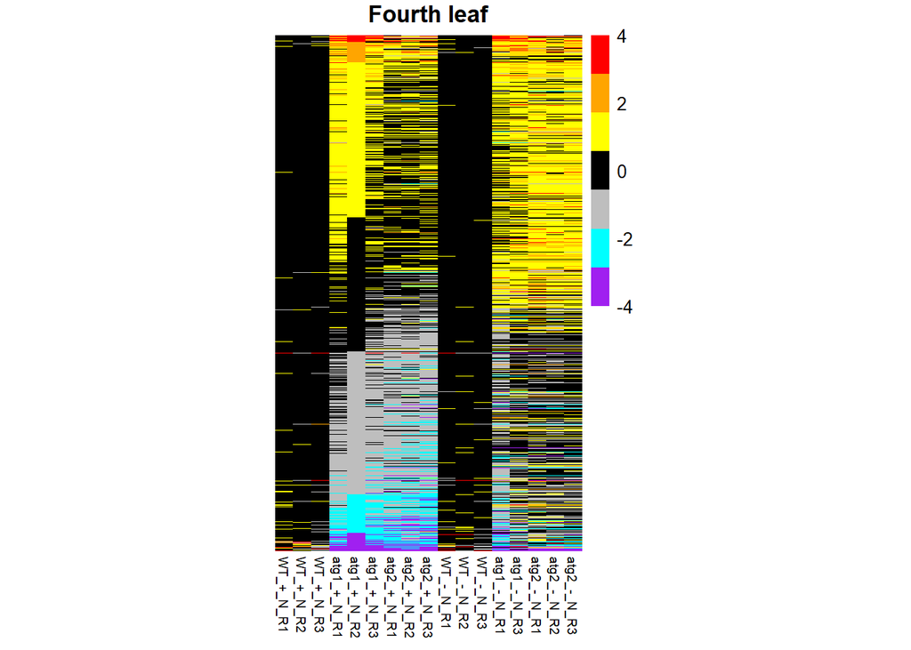

```r
pheatmap(Fourth_FC_matrix, cluster_rows = F, cluster_cols = F,
         col= c("purple","cyan","grey","black", "yellow", "orange", "red"),
         legend_labels = "-log2FC", show_rownames = F,
         fontsize_col = 7, cellwidth = 10, main = "Fourth leaf")
```

### Scatter plot for Fourth Leaf

```r
########## With Nitrogen
Fourth_N1_FC <- PostFC(Fourth_Ebseq_out_with_N1, SmallNum = 0.001)$PostFC %>% as.data.frame() %>% rownames_to_column(., var = "Genes") %>%
  rename(., `log2FC_atg1/wt` = `.`) %>%
  mutate(`log2FC_atg1/wt` = log2(`log2FC_atg1/wt`))

Fourth_N2_FC <- PostFC(Fourth_Ebseq_out_with_N2, SmallNum = 0.001)$PostFC %>% as.data.frame() %>% rownames_to_column(., var = "Genes") %>%
  rename(., `log2FC_atg2/wt` = `.`) %>%
  mutate(`log2FC_atg2/wt` = log2(`log2FC_atg2/wt`))

Fourth_Significant_DEG_N <- Fourth_DEG_with_N %>% as.data.frame() %>% rename(., Genes = `.`)

Fourth_N_PostFC <- inner_join(Fourth_N1_FC, Fourth_N2_FC, by = "Genes") %>%
  inner_join(., Fourth_Significant_DEG_N, by = "Genes")
########## Without Nitrogen
Fourth_1_FC <- PostFC(Ebseq_out_without_N1, SmallNum = 0.001)$PostFC %>% as.data.frame() %>% rownames_to_column(., var = "Genes") %>%
  rename(., `log2FC_atg1/wt` = `.`) %>%
  mutate(`log2FC_atg1/wt` = log2(`log2FC_atg1/wt`))

Fourth_2_FC <- PostFC(Ebseq_out_without_N2, SmallNum = 0.001)$PostFC %>% as.data.frame() %>% rownames_to_column(., var = "Genes") %>%
  rename(., `log2FC_atg2/wt` = `.`) %>%
  mutate(`log2FC_atg2/wt` = log2(`log2FC_atg2/wt`))

Fourth_Significant_DEG <- Fourth_DEG_without_N %>% as.data.frame() %>% rename(., Genes = `.`)

Fourth_PostFC <- inner_join(Fourth_1_FC, Fourth_2_FC, by = "Genes")%>%
  inner_join(., Fourth_Significant_DEG, by = "Genes")
```

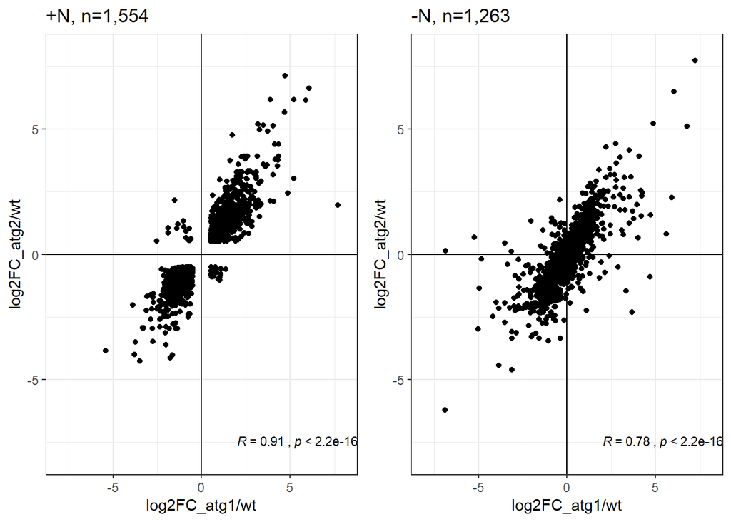

```r
scatter3<- ggplot(Fourth_N_PostFC, aes(x = `log2FC_atg1/wt`, y = `log2FC_atg2/wt`)) +
  geom_point() + theme_bw() + geom_hline(yintercept = 0) + geom_vline(xintercept = 0) +
  expand_limits(x = c(-8, 8), y = c(-8, 8)) + ggtitle( "+N, n=1,554") +
  stat_cor(method = "pearson", label.x = 2, label.y = -7.5, size = 3)


scatter4<-ggplot(Fourth_PostFC, aes(x = `log2FC_atg1/wt`, y = `log2FC_atg2/wt`)) + geom_point() +
  theme_bw() + geom_hline(yintercept = 0) + geom_vline(xintercept = 0) +
  expand_limits(x = c(-8, 8), y = c(-8, 8)) + ggtitle("-N, n=1,263") +
  stat_cor(method = "pearson", label.x = 2, label.y = -7.5, size = 3)

ggarrange(scatter3, scatter4)
```

### Principal component analysis for Fourth leaf

```r
Fourth_DEgenes_matrix_pca <- Fourth_DEgenes_matrix %>%
  column_to_rownames(., var = "DEG") %>% as.matrix()

Fourth_sizes_all <- MedianNorm(Fourth_DEgenes_matrix_pca)
Fourth_Norm_DEgenes_matrix_pca <- GetNormalizedMat(Fourth_DEgenes_matrix_pca,
                                                   Fourth_sizes_all)

Fourth_PCA_data <- Fourth_Norm_DEgenes_matrix_pca %>% as.data.frame() %>%
  rownames_to_column(., var = "Genes") %>%
  inner_join(., Fourth_DEG_all, by = c("Genes"= ".")) %>%
  column_to_rownames(., var = "Genes") %>% as.matrix() %>%
  t() %>% as.data.frame() %>% rownames_to_column(., var = "Genotypes") %>%
  mutate(Group = ifelse(grepl("WT_-", Genotypes), "WT_-N",
                        ifelse(grepl("WT_+", Genotypes), "WT_+N",
                        ifelse(grepl("atg1_-", Genotypes),"atg1_-N",
                        ifelse(grepl("atg1_+", Genotypes),"atg1_+N",
                        ifelse(grepl("atg2_-", Genotypes),"atg2_-N",
                        "atg2_+N")))))) %>%
  select(Group, Genotypes, everything())
```

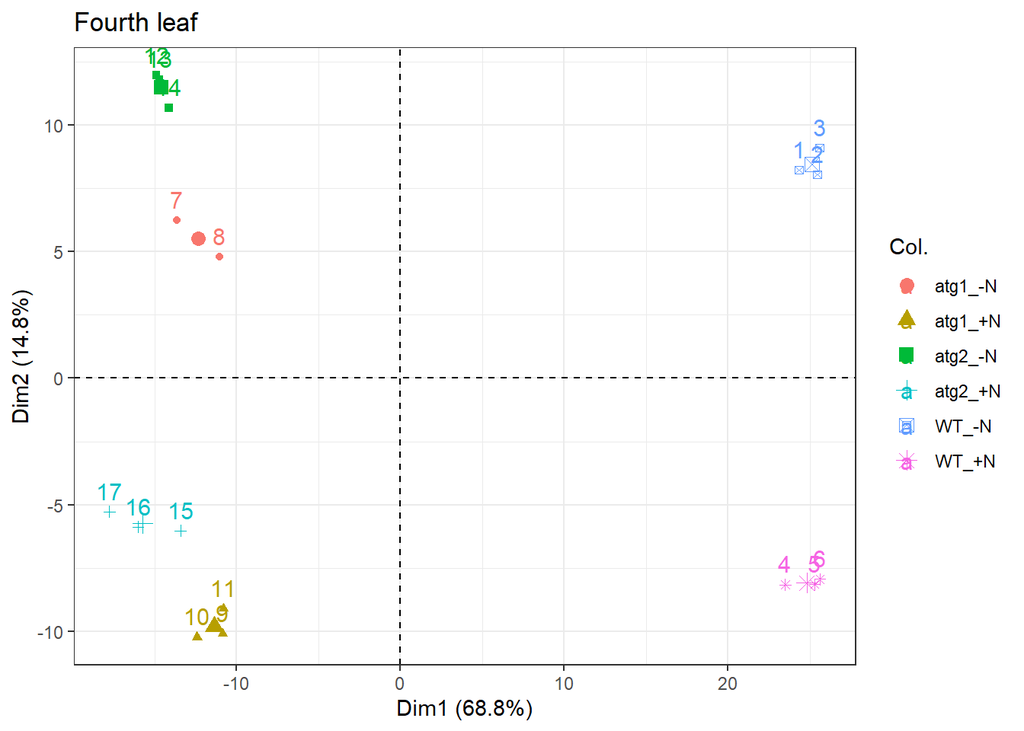

```r
library(FactoMineR)
library(factoextra)

pca = PCA(Fourth_PCA_data[,-(1:2)], scale.unit = T, ncp = 5, graph = F)

biplot = fviz_pca_ind(pca,  col.ind= Fourth_PCA_data$Group,
                      title = "Fourth leaf") + theme_bw()

biplot
```

```r
`Second_leaf_N+` <-  DEG_with_N %>% na.omit()

`Second_leaf_N-` <-  DEG_without_N %>% na.omit()

`Fourth_leaf_N-` <-  Fourth_DEG_without_N %>% na.omit()

`Fourth_leaf_N+` <-  Fourth_DEG_with_N %>% na.omit()

print(venn.diagram(x = list(`Second_leaf_N+` = `Second_leaf_N+`,
                      `Fourth_leaf_N-` = `Fourth_leaf_N-`,
                      `Second_leaf_N-` = `Second_leaf_N-`,
                      `Fourth_leaf_N+` = `Fourth_leaf_N+`),
             filename = "venn_diagram.tiff",
             fill = c("sky blue", "salmon", "pink","green"), cat.cex = 0.7))
```

```
## [1] 1
```

Let us now work on the GO enrichment bargraph

```r
# Now, we can import back the results from AgriGO

go_data <- read_tsv("./GO_enrichment.txt")
```

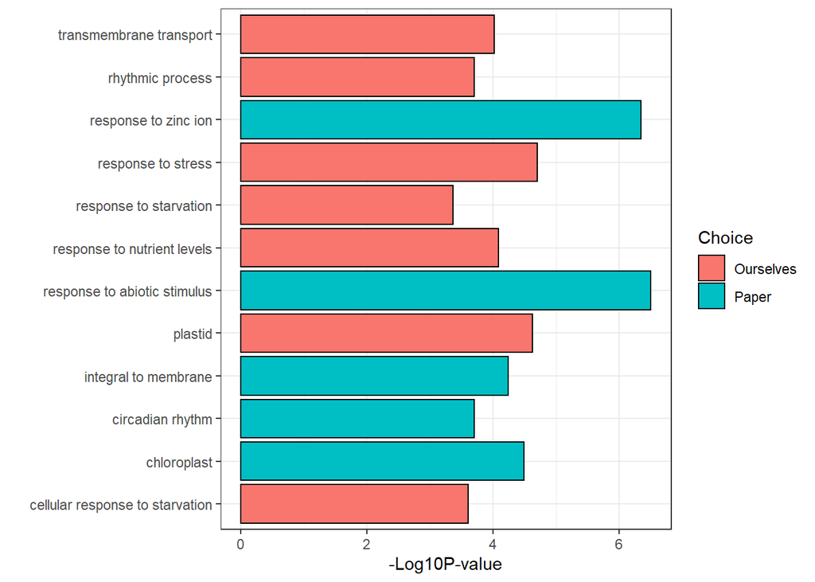

```r
go <- go_data %>% as.data.frame() %>%
  select(Description, FDR, `(-)Log10P-value`, Choice) %>%
  filter(., Choice %in% c("Paper", "Ourselves")) %>%
  arrange(desc(Description))

ggplot(go, aes(x = Description, y = `(-)Log10P-value`, fill = Choice)) +
  geom_col(color = "black") + theme_bw() + coord_flip() +
  labs(x = "", y = "-Log10P-value")
```